# Assignment 4: Demand Function Estimation II

Kohei Kawaguchi

2019/1/29

## Simulate data

**Be carefull that some parameters are changed from assignment 3**. We simulate data from a discrete choice model that is the same with in assignment 3 except for the existence of unobserved product-specific fixed effects. There are $T$ markets and each market has $N$ consumers. There are $J$ products and the indirect utility of consumer $i$ in market $t$ for product $j$ is:
$$u_{itj} = \beta_{it}' x_j + \alpha_{it} p_{jt} + \xi_{jt} +
\epsilon_{ijt},$$
where $\epsilon_{ijt}$ is an i.i.d. type-I extreme random variable. $x_j$ is $K$-dimensional observed characteristics of the product. $p_{jt}$ is the retail price of the product in the market.

$\xi_{jt}$ is product-market specific fixed effect. $p_{jt}$ can be correlated with $\xi_{jt}$ but $x_{jt}$s are independent of $\xi_{jt}$. $j = 0$ is an outside option whose indirect utility is:
$$u_{it0} = \epsilon_{i0t},$$
where $\epsilon_{i0t}$ is an i.i.d. type-I extreme random variable.

$\beta_{it}$ and $\alpha_{it}$ are different across consumers, and they are distributed as:
$$\beta_{itk} = \beta_{0k} + \sigma_k \nu_{itk},$$
$$\alpha_{it} = - \exp(\mu + \omega \upsilon_{it}) = - \exp(\mu +
\frac{\omega^2}{2}) + [- \exp(\mu + \omega \upsilon_{it}) + \exp(\mu +
\frac{\omega^2}{2})] \equiv \alpha_0 + \tilde{\alpha}_{it},$$
where $\nu_{itk}$ for $k = 1, \cdots, K$ and $\upsilon_{it}$ are i.i.d. standard normal random variables. $\alpha_0$ is the mean of $\alpha_i$ and $\tilde{\alpha}_i$ is the deviation from the mean.

Given a choice set in the market, $\mathcal{J}_t \cup \{0\}$, a consumer chooses the alternative that maximizes her utility:
$$q_{ijt} = 1\{u_{ijt} = \max_{k \in \mathcal{J}_t \cup \{0\}} u_{ikt}\}.$$
The choice probability of product $j$ for consumer $i$ in market $t$ is:
$$\sigma_{jt}(p_t, x_t, \xi_t) = \mathbb{P}\{u_{ijt} = \max_{k \in
\mathcal{J}_t \cup \{0\}} u_{ikt}\}.$$

Suppose that we only observe the share data:
$$s_{jt} = \frac{1}{N} \sum_{i = 1}^N q_{ijt},$$
along with the product-market characteristics $x_{jt}$ and the retail prices $p_{jt}$ for $j \in \mathcal{J}_t \cup \{0\}$ for $t = 1, \cdots, T$. We do not observe the choice data $q_{ijt}$ nor shocks $\xi_{jt}, \nu_{it}, \upsilon_{it}, \epsilon_{ijt}$.

We draw $\xi_{jt}$ from i.i.d. normal distribution with mean 0 and standard deviation $\sigma_{\xi}$.

1. Set the seed, constants, and parameters of interest as follows.

```r
# set the seed
set.seed(1)
# number of products
J <- 10
# dimension of product characteristics including the intercept
K <- 3
# number of markets
T <- 100
# number of consumers per market
N <- 500
# number of Monte Carlo
L <- 500
```

```r
# set parameters of interests
beta <- rnorm(K);
beta[1] <- 4
beta
```

```
## [1]  4.0000000  0.1836433 -0.8356286
```

```r
sigma <- abs(rnorm(K)); sigma
```

```
## [1] 1.5952808 0.3295078 0.8204684
```

```r
mu <- 0.5
omega <- 1
```

Generate the covariates as follows.

The product-market characteristics:
$$x_{j1} = 1, x_{jk} \sim N(0, \sigma_x), k = 2, \cdots, K,$$
where $\sigma_x$ is referred to as `sd_x` in the code.

The product-market-specific unobserved fixed effect:
$$\xi_{jt} \sim N(0, \sigma_\xi),$$
where $\sigma_xi$ is referred to as `sd_xi` in the code.

The marginal cost of product $j$ in market $t$:
$$c_{jt} \sim \text{logNormal}(0, \sigma_c),$$
where $\sigma_c$ is referred to as `sd_c` in the code.

The retail price:
$$p_{jt} - c_{jt} \sim \text{logNorm}(\gamma \xi_{jt}, \sigma_p^2),$$
where $\gamma$ is referred to as `price_xi` and $\sigma_p$ as `sd_p` in the code. This price is not the equilibrium price. We will revisit this point in a subsequent assignment.

The value of the auxiliary parameters are set as follows:

```r
# set auxiliary parameters
price_xi <- 1
sd_x <- 2
sd_xi <- 0.1
sd_c <- 0.5
sd_p <- 0.01
```

2. `X` is the data frame such that a row contains the characteristics vector $x_{j}$ of a product and columns are product index and observed product characteristics. The dimension of the characteristics $K$ is specified above. Add the row of the outside option whose index is $0$ and all the characteristics are zero.

```r
# make product characteristics data
X <-
  matrix(
    sd_x * rnorm(J * (K - 1)),
    nrow = J
    )
X <-
  cbind(
    rep(1, J),
    X
    )
colnames(X) <- paste("x", 1:K, sep = "_")
X <-
  data.frame(j = 1:J, X) %>%
  tibble::as_tibble()
# add outside option
X <-
  rbind(
    rep(0, dim(X)[2]),
    X
    )
```

```r
X
```

```
## # A tibble: 11 × 4
##        j   x_1     x_2     x_3
##    <dbl> <dbl>   <dbl>   <dbl>
##  1     0     0  0       0
##  2     1     1  0.975  -0.0324
##  3     2     1  1.48    1.89
##  4     3     1  1.15    1.64
##  5     4     1 -0.611   1.19
##  6     5     1  3.02    1.84
##  7     6     1  0.780   1.56
##  8     7     1 -1.24    0.149
##  9     8     1 -4.43   -3.98
## 10     9     1  2.25    1.24
## 11    10     1 -0.0899 -0.112
```

3. `M` is the data frame such that a row contains the price $\xi_{jt}$, marginal cost $c_{jt}$, and price $p_{jt}$. After generating the variables, drop some products in each market. **In this assignment, we drop products in a different way from the last assignment**. In order to change the number of available products in each market, for each market, first draw $J_t$ from a discrete uniform distribution between $1$ and $J$. Then, drop products from each market using `dplyr::sample_frac` function with the realized number of available products. The variation in the available products is important for the identification of the distribution of consumer-level unobserved heterogeneity. Add the row of the outside option to each market whose index is $0$ and all the variables take value zero.

```r
# make market-product data
M <-
  expand.grid(
    j = 1:J,
    t = 1:T
    ) %>%
    tibble::as_tibble() %>%
    dplyr::mutate(
      xi = sd_xi * rnorm(J * T),
      c = exp(sd_c * rnorm(J * T)),
      p = exp(price_xi * xi + sd_p * rnorm(J * T)) + c
    )
M <-
  M %>%
  dplyr::group_by(t) %>%
  dplyr::sample_frac(size = purrr::rdunif(1, J) / J) %>%
  dplyr::ungroup()
# add outside option
outside <-
  data.frame(
    j = 0,
    t = 1:T,
    xi = 0,
    c = 0,
    p = 0
    )
M <-
  rbind(
    M,
    outside
    ) %>%
  dplyr::arrange(
    t,
    j
    )
```

```r
M
```

```
## # A tibble: 633 × 5
##        j     t      xi     c     p
##    <dbl> <int>   <dbl> <dbl> <dbl>
##  1     0     1  0      0      0
##  2     1     1 -0.0156 0.604  1.58
##  3     4     1  0.0418 1.30   2.35
##  4     0     2  0      0      0
##  5     1     2 -0.0394 0.890  1.87
##  6     3     2  0.110  2.29   3.40
##  7     4     2  0.0763 0.997  2.09
##  8     6     2 -0.0253 1.15   2.13
##  9     7     2  0.0697 0.613  1.68
## 10     8     2  0.0557 0.629  1.67
## # ℹ 623 more rows
```

4. Generate the consumer-level heterogeneity. `V` is the data frame such that a row contains the vector of shocks to consumer-level heterogeneity, $(\nu_{i}', \upsilon_i)$. They are all i.i.d. standard normal random variables.

```r
# make consumer-market data
V <-
  matrix(
    rnorm(N * T * (K + 1)),
    nrow = N * T
    )
colnames(V) <-
  c(
    paste("v_x", 1:K, sep = "_"),
    "v_p"
    )
V <-
  data.frame(
    expand.grid(
      i = 1:N,
      t = 1:T
      ),
    V
    ) %>%
  tibble::as_tibble()
```

```r
V
```

```
## # A tibble: 50,000 × 6
##        i     t  v_x_1   v_x_2  v_x_3     v_p
##    <int> <int>  <dbl>   <dbl>  <dbl>   <dbl>
##  1     1     1 -1.37   0.211   1.65   0.0141
##  2     2     1  1.37   0.378   1.35   0.387
##  3     3     1 -2.06  -0.0662 -2.45  -1.17
##  4     4     1 -0.992 -0.727  -1.33  -1.42
##  5     5     1  0.252  1.87    0.751  0.317
##  6     6     1 -1.06  -0.531   1.34  -0.224
##  7     7     1 -0.217  1.03    0.909 -0.593
##  8     8     1 -0.838 -0.861  -0.612  1.54
##  9     9     1  0.659 -1.43   -1.77   0.340
## 10    10     1  0.452 -0.239   0.138  0.695
## # ℹ 49,990 more rows
```

5. Join `X`, `M`, `V` using `dplyr::left_join` and name it `df`. `df` is the data frame such that a row contains variables for a consumer about a product that is available in a market.

```r
# make choice data
df <-
  expand.grid(
    t = 1:T,
    i = 1:N,
    j = 0:J
    ) %>%
    tibble::as_tibble() %>%
    dplyr::left_join(
      V,
      by = c("i", "t")
      ) %>%
    dplyr::left_join(
      X,
      by = c("j")
      ) %>%
    dplyr::left_join(
      M,
      by = c("j", "t")
      ) %>%
    dplyr::filter(!is.na(p)) %>%
    dplyr::arrange(
      t,
      i,
      j
      )
```

```r
df
```

```
## # A tibble: 316,500 × 13
##        t     i     j  v_x_1   v_x_2 v_x_3     v_p   x_1    x_2     x_3      xi
##    <int> <int> <dbl>  <dbl>   <dbl> <dbl>   <dbl> <dbl>  <dbl>   <dbl>   <dbl>
##  1     1     1     0 -1.37   0.211   1.65  0.0141     0  0      0       0
##  2     1     1     1 -1.37   0.211   1.65  0.0141     1  0.975 -0.0324 -0.0156
##  3     1     1     4 -1.37   0.211   1.65  0.0141     1 -0.611  1.19    0.0418
##  4     1     2     0  1.37   0.378   1.35  0.387      0  0      0       0
##  5     1     2     1  1.37   0.378   1.35  0.387      1  0.975 -0.0324 -0.0156
##  6     1     2     4  1.37   0.378   1.35  0.387      1 -0.611  1.19    0.0418
##  7     1     3     0 -2.06  -0.0662 -2.45 -1.17       0  0      0       0
##  8     1     3     1 -2.06  -0.0662 -2.45 -1.17       1  0.975 -0.0324 -0.0156
##  9     1     3     4 -2.06  -0.0662 -2.45 -1.17       1 -0.611  1.19    0.0418
## 10     1     4     0 -0.992 -0.727  -1.33 -1.42       0  0      0       0
## # ℹ 316,490 more rows
## # ℹ 2 more variables: c <dbl>, p <dbl>
```

6. Draw a vector of preference shocks `e` whose length is the same as the number of rows of `df`.

```r
# draw idiosyncratic shocks
e <- evd::rgev(dim(df)[1])
```

```r
head(e)
```

```
## [1]  0.1917775 -0.3312816  0.2428217  1.0164097  1.4761643  2.8297340
```

7. Write a function `compute_indirect_utility(df, beta, sigma, mu, omega)` that returns a vector whose element is the mean indirect utility of a product for a consumer in a market. The output should have the same length with $e$. (This function is the same with assignment 3. You can use the function.)

```r
# compute indirect utility
u <-
  compute_indirect_utility(
    df = df,
    beta = beta,
    sigma = sigma,
    mu = mu,
    omega = omega
    )
head(u)
```

```
##               u
## [1,]  0.0000000
## [2,] -0.6238974
## [3,] -1.6225075
## [4,]  0.0000000
## [5,]  2.6171184
## [6,]  0.6490776
```

In the previous assingment, we computed predicted share by simulating choice and taking their average. Instead, we compute the actual share by:
$$s_{jt} = \frac{1}{N} \sum_{i = 1}^N \frac{\exp[\beta_{it}' x_j +
\alpha_{it} p_{jt} + \xi_{jt}]}{1 + \sum_{k \in \mathcal{J}_t}
\exp[\beta_{it}' x_k + \alpha_{it} p_{kt} + \xi_{jt}]}$$
and the predicted share by:
$$\widehat{\sigma}_{j}(x, p_t, \xi_t) = \frac{1}{L} \sum_{l = 1}^L
\frac{\exp[\beta_{t}^{(l)\prime} x_j + \alpha_{t}^{(l)} p_{jt} +
\xi_{jt}]}{1 + \sum_{k \in \mathcal{J}_t} \exp[\beta_{t}^{(l)\prime} x_k
+ \alpha_{t}^{(l)} p_{kt} + \xi_{jt}]}.$$

8. To do so, write a function `compute_choice_smooth(X, M, V, beta, sigma, mu, omega)` in which the choice of each consumer is not:
   $$q_{ijt} = 1\{u_{ijt} = \max_{k \in \mathcal{J}_t \cup \{0\}} u_{ikt}\},$$
   but
   $$\tilde{q}_{ijt} = \frac{\exp(u_{ijt})}{1 + \sum_{k \in \mathcal{J}_t}
   \exp(u_{ikt})}.$$

```r
df_choice_smooth <-
  compute_choice_smooth(
    X = X,
    M = M,
    V = V,
    beta = beta,
    sigma = sigma,
    mu = mu,
    omega = omega
    )
summary(df_choice_smooth)
```

```
##        t                i               j             v_x_1
##  Min.   :  1.00   Min.   :  1.0   Min.   : 0.00   Min.   :-4.302781
##  1st Qu.: 23.00   1st Qu.:125.8   1st Qu.: 2.00   1st Qu.:-0.685539
##  Median : 48.00   Median :250.5   Median : 4.00   Median : 0.001041
##  Mean   : 49.67   Mean   :250.5   Mean   : 4.49   Mean   :-0.002541
##  3rd Qu.: 77.00   3rd Qu.:375.2   3rd Qu.: 7.00   3rd Qu.: 0.673061
##  Max.   :100.00   Max.   :500.0   Max.   :10.00   Max.   : 3.809895
##      v_x_2               v_x_3                v_p                 x_1
##  Min.   :-4.542122   Min.   :-3.957618   Min.   :-4.218131   Min.   :0.000
##  1st Qu.:-0.679702   1st Qu.:-0.672701   1st Qu.:-0.669446   1st Qu.:1.000
##  Median : 0.000935   Median : 0.003104   Median : 0.001976   Median :1.000
##  Mean   : 0.000478   Mean   : 0.003428   Mean   : 0.000017   Mean   :0.842
##  3rd Qu.: 0.673109   3rd Qu.: 0.678344   3rd Qu.: 0.670699   3rd Qu.:1.000
##  Max.   : 4.313621   Max.   : 4.244194   Max.   : 4.074300   Max.   :1.000
##       x_2               x_3                xi                   c
##  Min.   :-4.4294   Min.   :-3.9787   Min.   :-0.2996949   Min.   :0.0000
##  1st Qu.:-0.6108   1st Qu.: 0.0000   1st Qu.:-0.0527368   1st Qu.:0.5250
##  Median : 0.7797   Median : 1.1878   Median : 0.0000000   Median :0.8775
##  Mean   : 0.3015   Mean   : 0.5034   Mean   :-0.0005149   Mean   :0.9507
##  3rd Qu.: 1.4766   3rd Qu.: 1.6424   3rd Qu.: 0.0556663   3rd Qu.:1.3203
##  Max.   : 3.0236   Max.   : 1.8877   Max.   : 0.3810277   Max.   :4.3043
##        p               u                  q
##  Min.   :0.000   Min.   :-345.287   Min.   :0.000000
##  1st Qu.:1.516   1st Qu.:  -3.030   1st Qu.:0.001435
##  Median :1.916   Median :   0.000   Median :0.030121
##  Mean   :1.797   Mean   :  -1.869   Mean   :0.157978
##  3rd Qu.:2.336   3rd Qu.:   1.559   3rd Qu.:0.161379
##  Max.   :5.513   Max.   :  22.434   Max.   :1.000000
```

9. Next, write a function `compute_share_smooth(X, M, V, beta, sigma, mu, omega)` that calls `compute_choice_smooth` and then returns the share based on above $\tilde{q}_{ijt}$. If we use these functions with the Monte Carlo shocks, it gives us the predicted share of the products.

```r
df_share_smooth <-
  compute_share_smooth(
    X = X,
    M = M,
    V = V,
    beta = beta,
    sigma = sigma,
    mu = mu,
    omega = omega
    )
summary(df_share_smooth)
```

```
##        t                j              x_1             x_2
##  Min.   :  1.00   Min.   : 0.00   Min.   :0.000   Min.   :-4.4294
##  1st Qu.: 23.00   1st Qu.: 2.00   1st Qu.:1.000   1st Qu.:-0.6108
##  Median : 48.00   Median : 4.00   Median :1.000   Median : 0.7797
##  Mean   : 49.67   Mean   : 4.49   Mean   :0.842   Mean   : 0.3015
##  3rd Qu.: 77.00   3rd Qu.: 7.00   3rd Qu.:1.000   3rd Qu.: 1.4766
##  Max.   :100.00   Max.   :10.00   Max.   :1.000   Max.   : 3.0236
##       x_3                xi                   c                p
##  Min.   :-3.9787   Min.   :-0.2996949   Min.   :0.0000   Min.   :0.000
##  1st Qu.: 0.0000   1st Qu.:-0.0527368   1st Qu.:0.5250   1st Qu.:1.516
##  Median : 1.1878   Median : 0.0000000   Median :0.8775   Median :1.916
##  Mean   : 0.5034   Mean   :-0.0005149   Mean   :0.9507   Mean   :1.797
##  3rd Qu.: 1.6424   3rd Qu.: 0.0556663   3rd Qu.:1.3203   3rd Qu.:2.336
##  Max.   : 1.8877   Max.   : 0.3810277   Max.   :4.3043   Max.   :5.513
##        q                 s                  y
##  Min.   :  1.748   Min.   :0.003497   Min.   :-4.23971
##  1st Qu.: 17.982   1st Qu.:0.035964   1st Qu.:-1.95098
##  Median : 40.241   Median :0.080483   Median :-1.22808
##  Mean   : 78.989   Mean   :0.157978   Mean   :-1.15979
##  3rd Qu.:123.006   3rd Qu.:0.246011   3rd Qu.:-0.03626
##  Max.   :325.631   Max.   :0.651262   Max.   : 1.26578
```

Use this `df_share_smooth` as the data to estimate the parameters in the following section.

## Estimate the parameters

1. First draw Monte Carlo consumer-level heterogeneity `V_mcmc` and Monte Carlo preference shocks `e_mcmc`. The number of simulations is `L`. This does not have to be the same with the actual number of consumers `N`.

```r
# mixed logit estimation
## draw mcmc V
V_mcmc <-
  matrix(
    rnorm(L * T * (K + 1)),
    nrow = L * T
    )
colnames(V_mcmc) <-
  c(
    paste("v_x", 1:K, sep = "_"),
    "v_p"
    )
V_mcmc <-
  data.frame(
  expand.grid(
    i = 1:L,
    t = 1:T
    ),
  V_mcmc
  ) %>%
  tibble::as_tibble()
```

```r
V_mcmc
```

```
## # A tibble: 50,000 × 6
##        i     t   v_x_1  v_x_2   v_x_3    v_p
##    <int> <int>   <dbl>  <dbl>   <dbl>  <dbl>
##  1     1     1  0.488  -1.51   0.528  -0.468
##  2     2     1  1.16    0.507 -0.527  -0.516
##  3     3     1 -2.49   -0.318 -0.0996 -0.893
##  4     4     1  0.0952 -0.133 -2.05    1.92
##  5     5     1 -1.11    0.103  2.24    0.753
##  6     6     1  0.903   0.496  0.287   1.53
##  7     7     1  0.913  -0.144  0.129  -1.17
##  8     8     1 -1.52    0.357 -0.475  -0.736
##  9     9     1  0.643   0.219  0.815  -1.27
## 10    10     1 -0.358   0.272 -0.650  -2.09
## # ℹ 49,990 more rows
```

```r
## draw mcmc e
df_mcmc <-
  expand.grid(
    t = 1:T,
    i = 1:L,
    j = 0:J
    ) %>%
    tibble::as_tibble() %>%
    dplyr::left_join(
      V_mcmc,
      by = c("i", "t")
      ) %>%
    dplyr::left_join(
      X,
      by = c("j")
      ) %>%
    dplyr::left_join(
      M,
      by = c("j", "t")
      ) %>%
    dplyr::filter(!is.na(p)) %>%
    dplyr::arrange(
      t,
      i,
      j
      )
# draw idiosyncratic shocks
e_mcmc <- evd::rgev(dim(df_mcmc)[1])
```

```r
head(e_mcmc)
```

```
## [1]  0.1006013  2.7039824  1.0540278  2.4697389  1.6721181 -1.0283872
```

2. Vectorize the parameters to a vector `theta` because `optim` requires the maximiand to be a vector.

```r
# set parameters
theta <-
  c(
    beta,
    sigma,
    mu,
    omega
    )
theta
```

```
## [1]  4.0000000  0.1836433 -0.8356286  1.5952808  0.3295078  0.8204684  0.5000000
## [8]  1.0000000
```

3. Estimate the parameters assuming there is no product-specific unobserved fixed effects $\xi_{jt}$, i.e., using the functions in assignment 3. To do so, first modify `M` to `M_no` in which `xi` is replaced with 0 and estimate the model with `M_no`. Otherwise, your function will compute the share with the true `xi`.

```r
M_no <-
  M %>%
  dplyr::mutate(xi = 0)
```

[output not shown]

```
##         true  estimates
## 1  4.0000000  4.0467164
## 2  0.1836433  0.1707430
## 3 -0.8356286 -0.8092369
## 4  1.5952808  1.8086380
## 5  0.3295078  0.3718435
## 6  0.8204684  0.7275257
## 7  0.5000000  0.4892642
## 8  1.0000000  1.0453963
```

Next, we estimate the model allowing for the product-market-specific unobserved fixed effect $\xi_{jt}$ using the BLP algorithm. To do so, we slightly modify the `compute_indirect_utility`, `compute_choice_smooth`, and `compute_share_smooth` functions so that they receive $\delta_{jt}$ to compute the indirect utilities, choices, and shares. Be careful that the treatment of $\alpha_i$ is slightly different from the lecture note, because we assumed that $\alpha_i$s are log-normal random variables.

4. Compute and print out $\delta_{jt}$ at the true parameters, i.e.:
   $$\delta_{jt} = \beta_0' x_j + \alpha_0' p_{jt} + \xi_{jt}.$$

```r
delta
```

```
## # A tibble: 633 × 3
##        t     j  delta
##    <int> <dbl>  <dbl>
##  1     1     0  0
##  2     1     1 -0.115
##  3     1     4 -3.46
##  4     2     0  0
##  5     2     1 -0.920
##  6     2     3 -6.29
##  7     2     4 -2.70
##  8     2     6 -2.97
##  9     2     7 -0.846
## 10     2     8  2.04
## # ℹ 623 more rows
```

5. Write a function `compute_indirect_utility_delta(df, delta, sigma, mu, omega)` that returns a vector whose element is the mean indirect utility of a product for a consumer in a market. The output should have the same length with $e$. Print out the output with $\delta_{jt}$ evaluated at the true parameters. Check if the output is close to the true indirect utilities.

```r
# compute indirect utility from delta
u_delta <-
  compute_indirect_utility_delta(
    df,
    delta,
    sigma,
    mu,
    omega
    )
head(u_delta)
```

```
##               u
## [1,]  0.0000000
## [2,] -0.6238974
## [3,] -1.6225075
## [4,]  0.0000000
## [5,]  2.6171184
## [6,]  0.6490776
```

```r
summary(u - u_delta)
```

```
##        u
##  Min.   :-5.684e-14
##  1st Qu.:-4.441e-16
##  Median : 0.000e+00
##  Mean   : 1.388e-17
##  3rd Qu.: 3.331e-16
##  Max.   : 5.684e-14
```

6. Write a function `compute_choice_smooth_delta(X, M, V, delta, sigma, mu, omega)` that first construct `df` from `X`, `M`, `V`, second call `compute_indirect_utility_delta` to obtain the vector of mean indirect utilities `u`, third compute the (smooth) choice vector `q` based on the vector of mean indirect utilities, and finally return the data frame to which `u` and `q` are added as columns. Print out the output with $\delta_{jt}$ evaluated at the true parameters. Check if the output is close to the true (smooth) choice vector.

```r
# compute choice
df_choice_smooth_delta <-
  compute_choice_smooth_delta(
    X,
    M,
    V,
    delta,
    sigma,
    mu,
    omega
    )
df_choice_smooth_delta
```

```
## # A tibble: 316,500 × 15
##        t     i     j  v_x_1   v_x_2 v_x_3     v_p   x_1    x_2     x_3      xi
##    <int> <int> <dbl>  <dbl>   <dbl> <dbl>   <dbl> <dbl>  <dbl>   <dbl>   <dbl>
##  1     1     1     0 -1.37   0.211   1.65  0.0141     0  0      0       0
##  2     1     1     1 -1.37   0.211   1.65  0.0141     1  0.975 -0.0324 -0.0156
##  3     1     1     4 -1.37   0.211   1.65  0.0141     1 -0.611  1.19    0.0418
##  4     1     2     0  1.37   0.378   1.35  0.387      0  0      0       0
##  5     1     2     1  1.37   0.378   1.35  0.387      1  0.975 -0.0324 -0.0156
##  6     1     2     4  1.37   0.378   1.35  0.387      1 -0.611  1.19    0.0418
##  7     1     3     0 -2.06  -0.0662 -2.45 -1.17       0  0      0       0
##  8     1     3     1 -2.06  -0.0662 -2.45 -1.17       1  0.975 -0.0324 -0.0156
##  9     1     3     4 -2.06  -0.0662 -2.45 -1.17       1 -0.611  1.19    0.0418
## 10     1     4     0 -0.992 -0.727  -1.33 -1.42       0  0      0       0
## # ℹ 316,490 more rows
## # ℹ 4 more variables: c <dbl>, p <dbl>, u <dbl>, q <dbl>
```

```r
summary(df_choice_smooth_delta)
```

```
##        t                i               j             v_x_1
##  Min.   :  1.00   Min.   :  1.0   Min.   : 0.00   Min.   :-4.302781
##  1st Qu.: 23.00   1st Qu.:125.8   1st Qu.: 2.00   1st Qu.:-0.685539
##  Median : 48.00   Median :250.5   Median : 4.00   Median : 0.001041
##  Mean   : 49.67   Mean   :250.5   Mean   : 4.49   Mean   :-0.002541
##  3rd Qu.: 77.00   3rd Qu.:375.2   3rd Qu.: 7.00   3rd Qu.: 0.673061
##  Max.   :100.00   Max.   :500.0   Max.   :10.00   Max.   : 3.809895
##      v_x_2               v_x_3                v_p                 x_1
##  Min.   :-4.542122   Min.   :-3.957618   Min.   :-4.218131   Min.   :0.000
##  1st Qu.:-0.679702   1st Qu.:-0.672701   1st Qu.:-0.669446   1st Qu.:1.000
##  Median : 0.000935   Median : 0.003104   Median : 0.001976   Median :1.000
##  Mean   : 0.000478   Mean   : 0.003428   Mean   : 0.000017   Mean   :0.842
##  3rd Qu.: 0.673109   3rd Qu.: 0.678344   3rd Qu.: 0.670699   3rd Qu.:1.000
##  Max.   : 4.313621   Max.   : 4.244194   Max.   : 4.074300   Max.   :1.000
##       x_2               x_3                xi                   c
##  Min.   :-4.4294   Min.   :-3.9787   Min.   :-0.2996949   Min.   :0.0000
##  1st Qu.:-0.6108   1st Qu.: 0.0000   1st Qu.:-0.0527368   1st Qu.:0.5250
##  Median : 0.7797   Median : 1.1878   Median : 0.0000000   Median :0.8775
##  Mean   : 0.3015   Mean   : 0.5034   Mean   :-0.0005149   Mean   :0.9507
##  3rd Qu.: 1.4766   3rd Qu.: 1.6424   3rd Qu.: 0.0556663   3rd Qu.:1.3203
##  Max.   : 3.0236   Max.   : 1.8877   Max.   : 0.3810277   Max.   :4.3043
##        p               u                  q
##  Min.   :0.000   Min.   :-345.287   Min.   :0.000000
##  1st Qu.:1.516   1st Qu.:  -3.030   1st Qu.:0.001435
##  Median :1.916   Median :   0.000   Median :0.030121
##  Mean   :1.797   Mean   :  -1.869   Mean   :0.157978
##  3rd Qu.:2.336   3rd Qu.:   1.559   3rd Qu.:0.161379
##  Max.   :5.513   Max.   :  22.434   Max.   :1.000000
```

```r
summary(df_choice_smooth$q - df_choice_smooth_delta$q)
```

```
##       Min.    1st Qu.     Median       Mean    3rd Qu.       Max.
## -9.437e-16 -6.939e-18  0.000e+00 -1.050e-19  1.843e-18  9.992e-16
```

7. Write a function `compute_share_delta(X, M, V, delta, sigma, mu, omega)` that first construct `df` from `X`, `M`, `V`, second call `compute_choice_delta` to obtain a data frame with `u` and `q`, third compute the share of each product at each market `s` and the log difference in the share from the outside option, $\ln(s_{jt}/s_{0t})$, denoted by `y`, and finally return the data frame that is summarized at the product-market level, dropped consumer-level variables, and added `s` and `y`.

```r
# compute share
df_share_smooth_delta <-
  compute_share_smooth_delta(
    X,
    M,
    V,
    delta,
    sigma,
    mu,
    omega
    )
df_share_smooth_delta
```

```
## # A tibble: 633 × 11
##        t     j   x_1    x_2     x_3      xi     c     p      q      s      y
##    <int> <dbl> <dbl>  <dbl>   <dbl>   <dbl> <dbl> <dbl>  <dbl>  <dbl>  <dbl>
##  1     1     0     0  0      0       0      0      0    199.   0.398   0
##  2     1     1     1  0.975 -0.0324 -0.0156 0.604  1.58 260.   0.521   0.270
##  3     1     4     1 -0.611  1.19    0.0418 1.30   2.35  40.8  0.0816 -1.58
##  4     2     0     0  0      0       0      0      0    106.   0.211   0
##  5     2     1     1  0.975 -0.0324 -0.0394 0.890  1.87  32.9  0.0658 -1.17
##  6     2     3     1  1.15   1.64    0.110  2.29   3.40   6.78 0.0136 -2.75
##  7     2     4     1 -0.611  1.19    0.0763 0.997  2.09  14.1  0.0282 -2.01
##  8     2     6     1  0.780  1.56   -0.0253 1.15   2.13  17.4  0.0347 -1.81
##  9     2     7     1 -1.24   0.149   0.0697 0.613  1.68  25.2  0.0504 -1.43
## 10     2     8     1 -4.43  -3.98    0.0557 0.629  1.67 290.   0.580   1.01
## # ℹ 623 more rows
```

```r
summary(df_share_smooth_delta)
```

```
##        t                j              x_1             x_2
##  Min.   :  1.00   Min.   : 0.00   Min.   :0.000   Min.   :-4.4294
##  1st Qu.: 23.00   1st Qu.: 2.00   1st Qu.:1.000   1st Qu.:-0.6108
##  Median : 48.00   Median : 4.00   Median :1.000   Median : 0.7797
##  Mean   : 49.67   Mean   : 4.49   Mean   :0.842   Mean   : 0.3015
##  3rd Qu.: 77.00   3rd Qu.: 7.00   3rd Qu.:1.000   3rd Qu.: 1.4766
##  Max.   :100.00   Max.   :10.00   Max.   :1.000   Max.   : 3.0236
##       x_3                xi                   c                p
##  Min.   :-3.9787   Min.   :-0.2996949   Min.   :0.0000   Min.   :0.000
##  1st Qu.: 0.0000   1st Qu.:-0.0527368   1st Qu.:0.5250   1st Qu.:1.516
##  Median : 1.1878   Median : 0.0000000   Median :0.8775   Median :1.916
##  Mean   : 0.5034   Mean   :-0.0005149   Mean   :0.9507   Mean   :1.797
##  3rd Qu.: 1.6424   3rd Qu.: 0.0556663   3rd Qu.:1.3203   3rd Qu.:2.336
##  Max.   : 1.8877   Max.   : 0.3810277   Max.   :4.3043   Max.   :5.513
##        q                 s                  y
##  Min.   :  1.748   Min.   :0.003497   Min.   :-4.23971
##  1st Qu.: 17.982   1st Qu.:0.035964   1st Qu.:-1.95098
##  Median : 40.241   Median :0.080483   Median :-1.22808
##  Mean   : 78.989   Mean   :0.157978   Mean   :-1.15979
##  3rd Qu.:123.006   3rd Qu.:0.246011   3rd Qu.:-0.03626
##  Max.   :325.631   Max.   :0.651262   Max.   : 1.26578
```

```r
summary(df_share_smooth$s - df_share_smooth_delta$s)
```

```
##       Min.    1st Qu.     Median       Mean    3rd Qu.       Max.
## -1.665e-16 -1.388e-17  0.000e+00  5.549e-20  6.939e-18  2.220e-16
```

Start the algorithm with the true $\delta_{jt}$ and check if the algorithm returns (almost) the same $\delta_{jt}$ when the actual and predicted smooth share are equated.

```r
kappa <- 1
lambda <- 1e-4
delta_new <-
  solve_delta(
    df_share_smooth,
    X,
    M,
    V,
    delta,
    sigma,
    mu,
    omega,
    kappa,
    lambda
    )
head(delta_new)
```

```
## # A tibble: 6 × 3
##       t     j  delta
##   <int> <dbl>  <dbl>
## 1     1     0  0
## 2     1     1 -0.115
## 3     1     4 -3.46
## 4     2     0  0
## 5     2     1 -0.920
## 6     2     3 -6.29
```

```r
summary(delta_new$delta - delta$delta)
```

```
##       Min.    1st Qu.     Median       Mean    3rd Qu.       Max.
## -1.776e-15 -2.220e-16  0.000e+00 -1.193e-17  0.000e+00  1.776e-15
```

```r
delta_new <-
  solve_delta(
    df_share_smooth,
    X,
    M,
    V_mcmc,
    delta,
    sigma,
    mu,
    omega,
    kappa,
    lambda
  )
saveRDS(
  delta_new,
  file = "lecture/data/a4/delta_new.rds" %>% here::here()
)
```

```r
delta_new <-
  readRDS(
    file = "lecture/data/a4/delta_new.rds" %>% here::here()
  )
summary(delta_new$delta - delta$delta)
```

```
##     Min.  1st Qu.   Median     Mean  3rd Qu.     Max.
## -1.43733 -0.28081  0.00000 -0.01762  0.22132  1.12425
```

10. We use the marginal cost $c_{jt}$ as the excluded instrumental variable for $p_{jt}$. Let $\Psi$ be the weighing matrix for the GMM estimator. For now, let it be the identity matrix. Write a function `compute_theta_linear(df_share_smooth, delta, mu, omega, Psi)` that returns the optimal linear parameters associated with the data and $\delta$. Notice that we only obtain $\beta_0$ in this way because $\alpha_0$ is directly computed from the non-linear parameters by $-\exp(\mu + \omega^2/2)$. The first order condition for $\beta_0$ is:
    $$\begin{equation}
    \beta_0 = (X'W \Phi^{-1} W'X)^{-1} X' W \Phi^{-1} W'
    [\delta - \alpha_0 p],
    \end{equation}$$
    where

$$\begin{equation}
X =
\begin{pmatrix}
x_{11}'\\
\vdots \\
x_{J_1 1}'\\
\vdots \\
x_{1T}' \\
\vdots \\
x_{J_T T}
\end{pmatrix}
\end{equation}$$

$$\begin{equation}
W =
\begin{pmatrix}
x_{11}' & c_{11}\\
\vdots & \vdots \\
x_{J_1 1}' & c_{J_1 1}\\
\vdots & \vdots \\
x_{1T}' & c_{1T}\\
\vdots & \vdots \\
x_{J_T T} & c_{J_T T}
\end{pmatrix},
\end{equation}$$

$$\begin{equation}
\delta =
\begin{pmatrix}
\delta_11\\
\vdots\\
\delta_{J_1 1}\\
\vdots\\
\delta_1T\\
\vdots\\
\delta_{J_T T}\\
\end{pmatrix}
\end{equation}$$
,

where $\alpha_0 = - \exp(\mu + \omega^2/2)$. Notice that $X$ and $W$ does not include rows for the outwide option.

```r
Psi <- diag(length(beta) + 1)
theta_linear <-
  compute_theta_linear(
    df_share_smooth,
    delta,
    mu,
    omega,
    Psi
    )
cbind(
  theta_linear,
  beta
  )
```

```
##          delta       beta
## x_1  3.9946731  4.0000000
## x_2  0.1747411  0.1836433
## x_3 -0.8244048 -0.8356286
```

11. Write a function `solve_xi(df_share_smooth, delta, beta, mu, omega)` that computes the values of $\xi$ that are implied from the data, $\delta$, and the linear parameters. Check that the (almost) true values are returned when true $\delta$ and the true linear parmaeters are passed to the function. Notice that the returend $\xi$ should not include rows for the outside option.

```r
xi_new <-
  solve_xi(
    df_share_smooth,
    delta,
    beta,
    mu,
    omega
    )
head(xi_new)
```

```
##               xi
## [1,] -0.01557955
## [2,]  0.04179416
## [3,] -0.03942900
## [4,]  0.11000254
## [5,]  0.07631757
## [6,] -0.02533617
```

```r
xi_true <-
  df_share_smooth %>%
  dplyr::filter(j != 0) %>%
  dplyr::select(xi)
summary(xi_true - xi_new)
```

```
##        xi
##  Min.   :-4.233e-16
##  1st Qu.:-5.551e-17
##  Median : 0.000e+00
##  Mean   : 1.347e-17
##  3rd Qu.: 8.327e-17
##  Max.   : 8.604e-16
```

11. Write a function `compute_gmm_objective_a4(theta_nonlinear, delta, df_share_smooth, Psi, X, M, V_mcmc, kappa, lambda)` that returns the value of the GMM objective function as a function of non-linear parameters `mu`, `omega`, and `sigma`:
    $$\min_{\theta} \xi(\theta)' W \Phi^{-1} W' \xi(\theta),$$
    where $\xi(\theta)$ is the values of $\xi$ that solves:
    $$s = \sigma(p, x, \xi),$$
    given parameters $\theta$. Note that the row of $\xi(\theta)$ and $W$ do not include the rows for the outside options.

```r
# non-linear parmaeters
theta_nonlinear <-
  c(
    mu,
    omega,
    sigma
    )
```

```r
# compute GMM objective function
objective <-
  compute_gmm_objective_a4(
    theta_nonlinear,
    delta,
    df_share_smooth,
    Psi,
    X,
    M,
    V_mcmc,
    kappa,
    lambda
    )
saveRDS(
  objective,
  file = "lecture/data/a4/objective.rds" %>% here::here()
)
```

```r
objective <- readRDS(
  file = "lecture/data/a4/objective.rds" %>% here::here()
)
objective
```

```
##          xi
## xi 16.37845
```

12. Draw a graph of the objective function that varies each non-linear parameter from 0, 0.2, $\cdots$, 2.0 of the true value. Try with the actual shocks `V`.

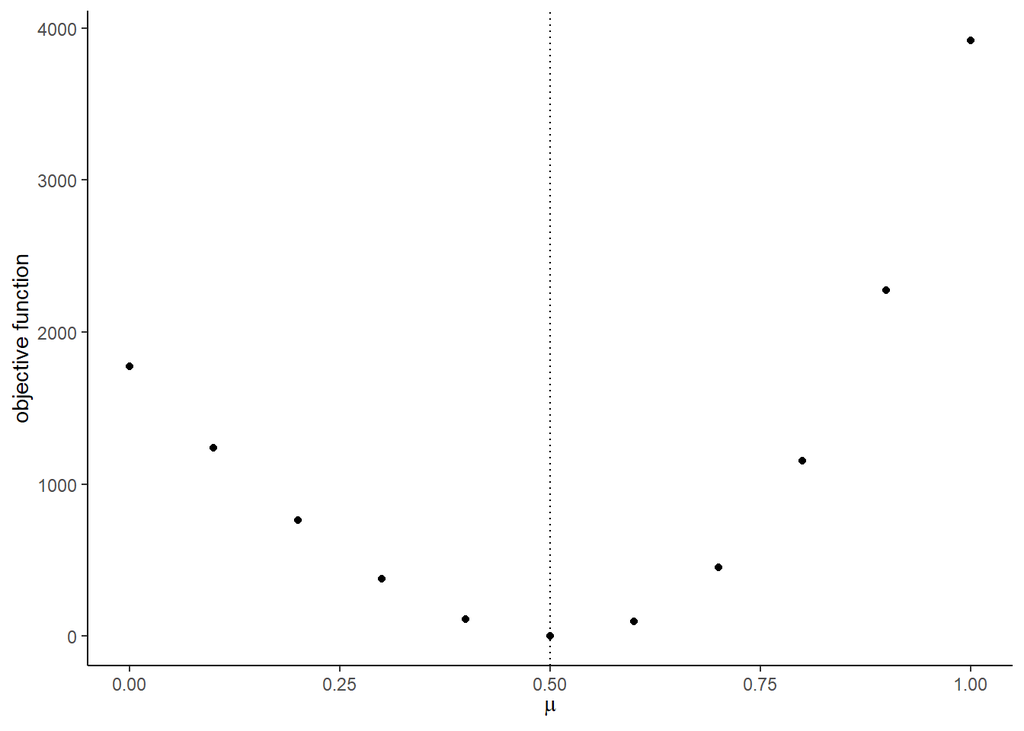

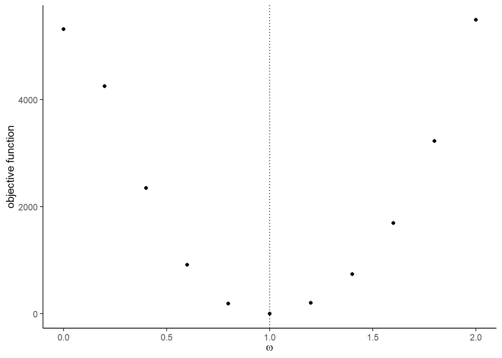

[figure not shown]

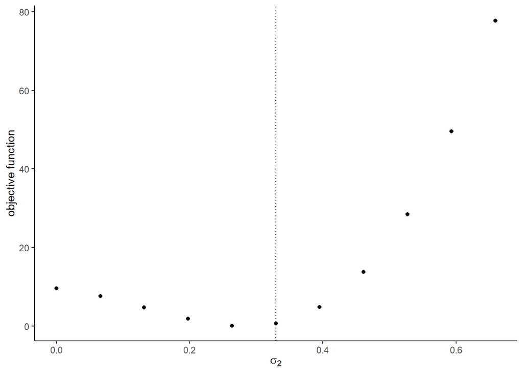

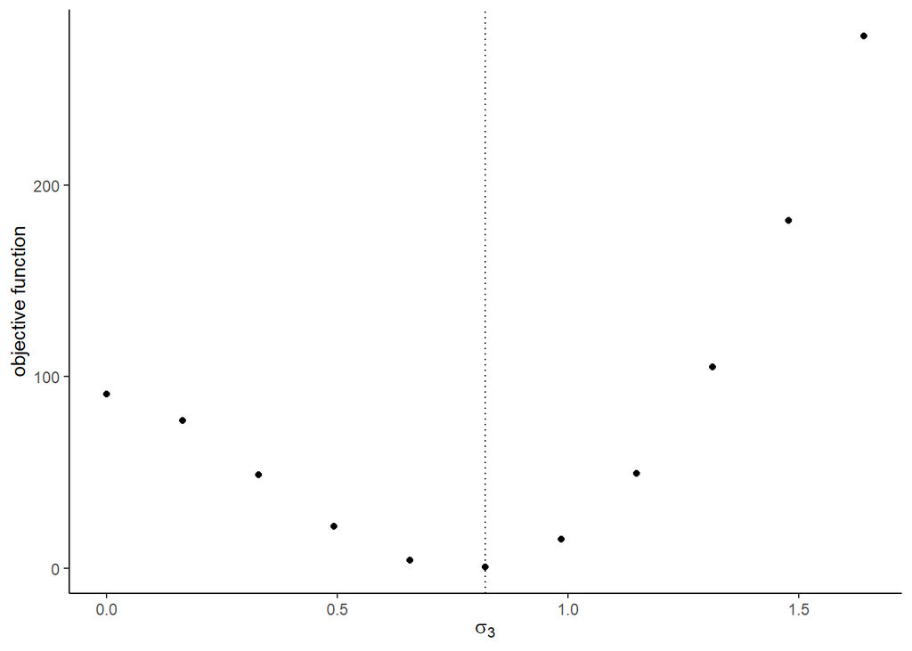

13. Find non-linear parameters that minimize the GMM objective function. Because standard deviations of the same absolute value with positive and negative values have almost the same implication for the data, you can take the absolute value if the estimates of the standard deviations happened to be negative (Another way is to set the non-negativity constraints on the standard deviations).

```
## $par
## [1] 0.4928139 1.0228455 1.5913062 0.3913233 0.8707353
##
## $value
## [1] 7.353949e-08
##
## $counts
## function gradient
##      140       NA
##
## $convergence
## [1] 0
##
## $message
## NULL
```

```
##           true  estimate
## [1,] 0.5000000 0.4928139
## [2,] 1.0000000 1.0228455
## [3,] 1.5952808 1.5913062
## [4,] 0.3295078 0.3913233
## [5,] 0.8204684 0.8707353
```